#### A short introduction to the package ggplot2

What is ggplot?:

- package written by Hadley Wickham
- based on ‘Grammar of Graphics’ by [Wilkinson 2005](https://www.amazon.de/Grammar-Graphics-Statistics-Computing/dp/0387245448) - a tool that enables us to concisely describe the components of a graphic
- idea: layer-based system that starts with the raw data and adds stats, annnotations etc. as new layers to the plot
- or in Wickham’s words: [“In brief, the grammar tells us that a statistical graphic is a mapping from data to aesthetic attributes (colour, shape, size) of geometric objects (points, lines, bars). The plot may also contain statistical transformations of the data and is drawn on a specific coordinates system.”](http://moderngraphics11.pbworks.com/f/ggplot2-Book09hWickham.pdf)
- useful links for ggplot:
1. [beautiful plotting with ggplot](http://zevross.com/blog/2014/08/04/beautiful-plotting-in-r-a-ggplot2-cheatsheet-3/#use-a-new-theme-theme_xx). This tutorial includes a list of all properties that can be defined the the “theme”-function. It will help you to edit or even create your own theme in ggplot!
2. [adding a second y-axis](http://docs.ggplot2.org/dev/sec_axis.html). This is part of the ggplot2-documentation and shows how to add a second y-axis to your plots
3. [official ggplot cheatsheet](https://www.rstudio.com/wp-content/uploads/2015/03/ggplot2-cheatsheet.pdf). The ggplot cheatsheet which is also uploaded to the repository and available in RStudio under Help -> Cheatsheets…
4. [Tidy Data](http://vita.had.co.nz/papers/tidy-data.pdf). This is the paper by Wickham, which tells you more about the concept of “tidy data”, which facilitates plotting with ggplot!

#### How to make a basic plot:

```r
library(ggplot2)
iris_test <- iris
head(iris_test)
```

```
##   Sepal.Length Sepal.Width Petal.Length Petal.Width Species
## 1          5.1         3.5          1.4         0.2  setosa
## 2          4.9         3.0          1.4         0.2  setosa
## 3          4.7         3.2          1.3         0.2  setosa
## 4          4.6         3.1          1.5         0.2  setosa
## 5          5.0         3.6          1.4         0.2  setosa
## 6          5.4         3.9          1.7         0.4  setosa
```

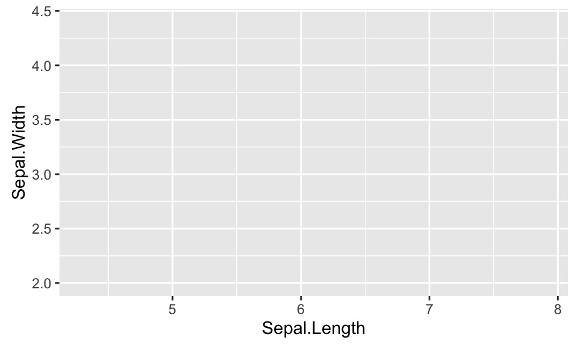

```r
ggplot(data=iris_test,aes(x=Sepal.Length, y=Sepal.Width, colours = factor(Species)))
```

As you can see, you don’t see anything… The reason is that so far we only specified **WHAT** we want to plot (aesthetics) and not **HOW** we want to plot it (geometric objects such as dots, lines, polygons or whatever). We do this by adding a **geom_** - layer:

##### Lineplot

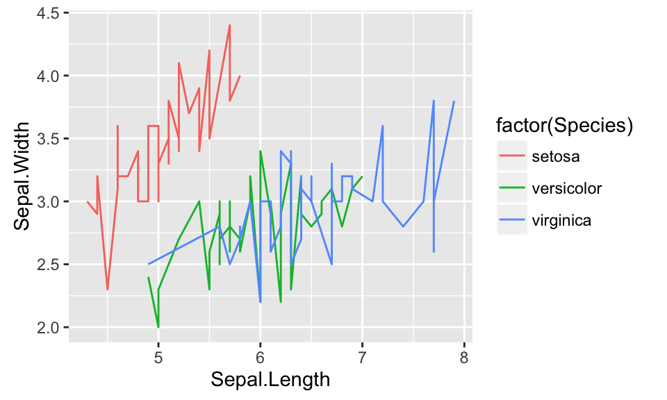

```r
ggplot(data=iris_test,aes(x=Sepal.Length, y=Sepal.Width, colour = factor(Species))) +
  geom_line()
```

##### Boxplot

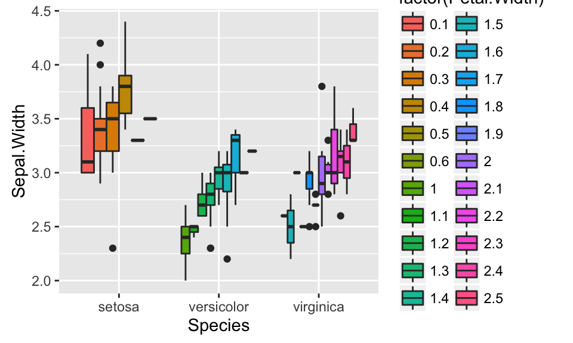

```r
ggplot(data=iris_test,aes(x=Species, y=Sepal.Width, fill = factor(Petal.Width))) +
  geom_boxplot()
```

##### Scatterplot

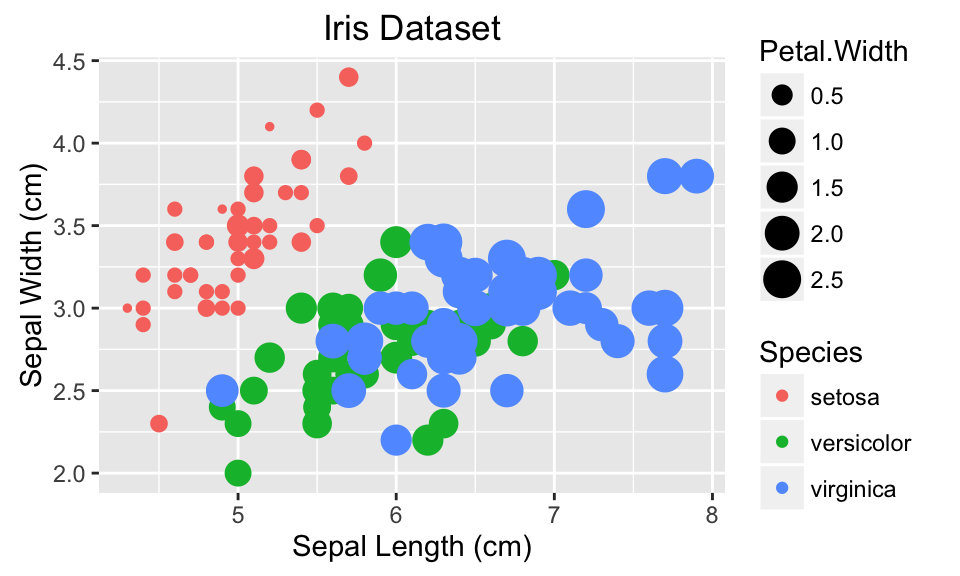

```r
ggplot(data=iris_test,aes(x=Sepal.Length, y=Sepal.Width, colour = factor(Species), size = Petal.Width)) +
  geom_point() +
 labs(x="Sepal Length (cm)", y="Sepal Width (cm)", col="Species", title="Iris Dataset")
```

##### Heatmap

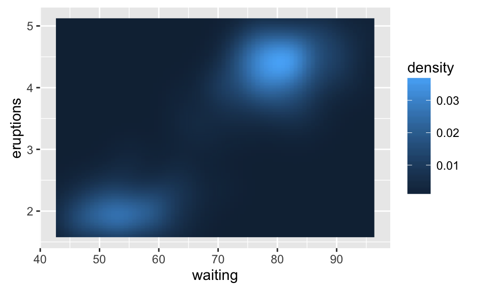

```r
ggplot(data=faithfuld,aes(x=waiting, y=eruptions)) +
  geom_raster(aes(fill=density),interpolate=T)
```

##### Facet plots

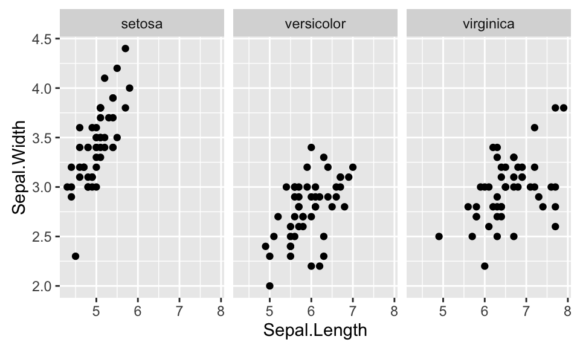

```r
#facet_wrap allows us to plot our data in seperate subplots, sorted by a factor.
ggplot(data=iris_test,aes(x=Sepal.Length, y=Sepal.Width)) +
  geom_point() +
  facet_wrap(~Species)
```

#### How to change

##### colours

Not happy with the colours? There are multiple ways to change that:

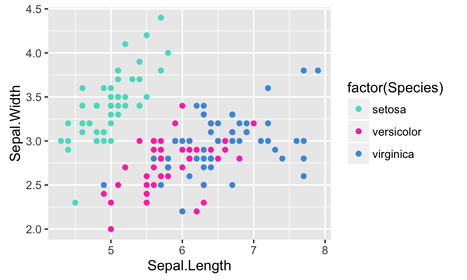

```r
#Define a vector of colours (in this case hex-codes to define them very precisely)
myColors <- c("#56ddc5", "#ff3db7", "#4699dd")
ggplot(data=iris_test,aes(x=Sepal.Length, y=Sepal.Width, colour = factor(Species))) +
  geom_point() +
  scale_color_manual(values=myColors)
```

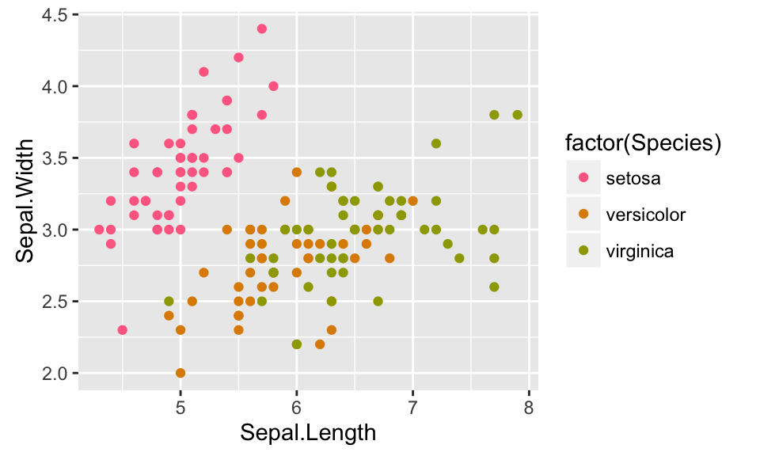

```r
#Use scale_colour_hue to create a colour gradient
ggplot(data=iris_test,aes(x=Sepal.Length, y=Sepal.Width, colour = factor(Species))) +
  geom_point() +
  scale_colour_hue(h=c(0, 90))
```

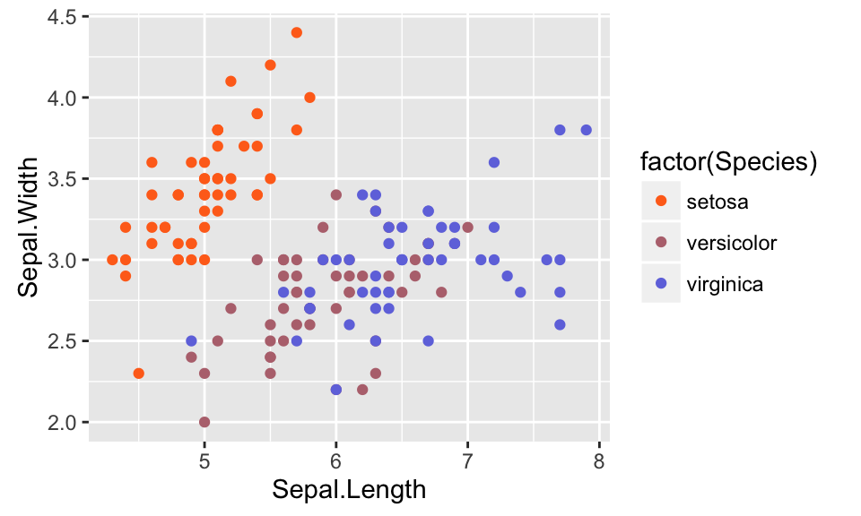

```r
#You can also define a gradient by hand...
#What is an advantage with this method is that you can define the colours more precisely via hex-codes
colfunc <- colorRampPalette(c("#ff6f1d", "#7077df"))
myColors <- colfunc(3)
ggplot(data=iris_test,aes(x=Sepal.Length, y=Sepal.Width, colour = factor(Species))) +
  geom_point() +
 scale_color_manual(values=myColors)
```

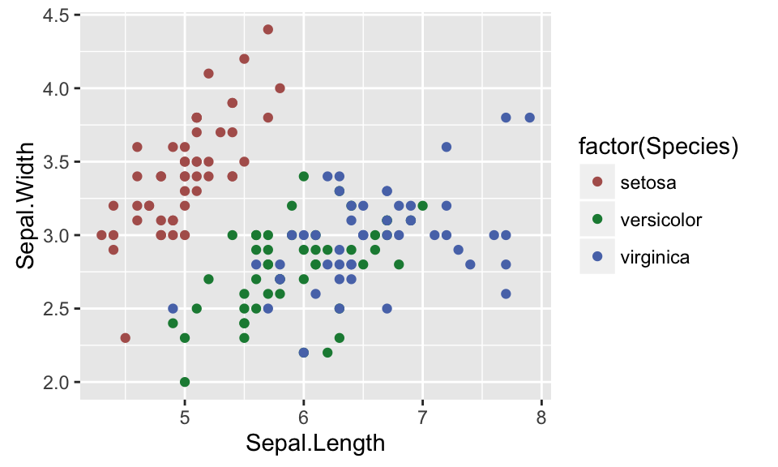

```r
#or simply manipulate the lightness (l) and chroma/intensity (c) of the used colours
ggplot(data=iris_test,aes(x=Sepal.Length, y=Sepal.Width, colour = factor(Species))) +
  geom_point() +
 scale_color_hue(l=50, c=60)
```

##### size

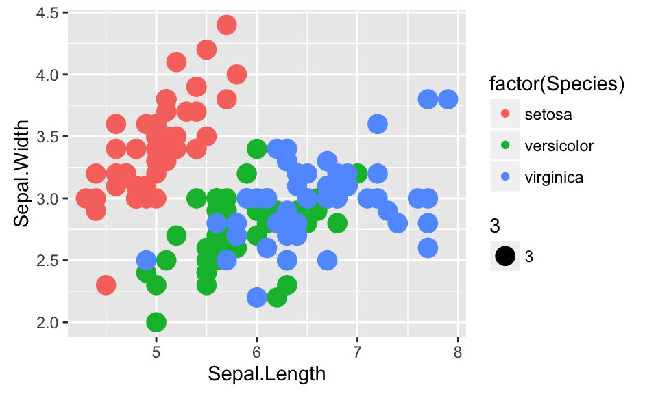

```r
#Change the symbol size to a fixed value
ggplot(data=iris_test,aes(x=Sepal.Length, y=Sepal.Width, colour = factor(Species),size=3)) +
  geom_point()
```

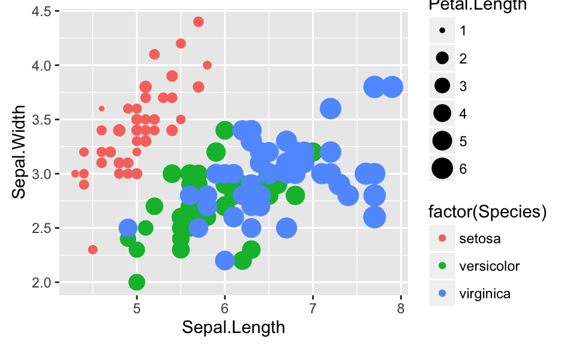

```r
#Change the symbol size according to a value
ggplot(data=iris_test,aes(x=Sepal.Length, y=Sepal.Width, colour = factor(Species),size=Petal.Length)) +
  geom_point()
```

##### shapes

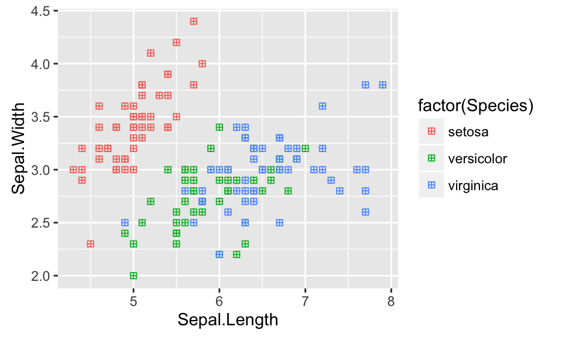

```r
#Change the symbol shape to a fixed one
ggplot(data=iris_test,aes(x=Sepal.Length, y=Sepal.Width, colour = factor(Species))) +
  geom_point(shape=12)
```

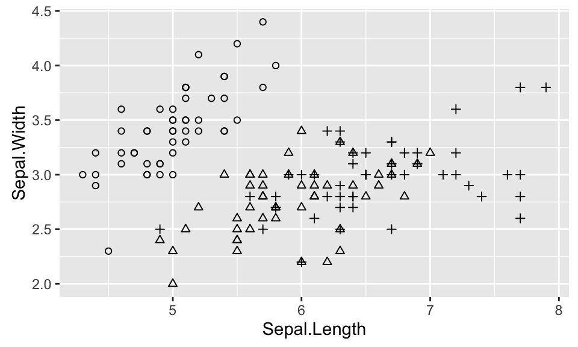

```r
#Change the symbol shape according to a factor
ggplot(data=iris_test,aes(x=Sepal.Length, y=Sepal.Width)) +
  geom_point(shape=factor(iris_test$Species))
```

And there are countless other ways to achieve that… Check the ggthemr and ggthemes packages which facilitate making major changes in your plot layout.

#### Include stats in your plots:

##### Add linear regression to plot

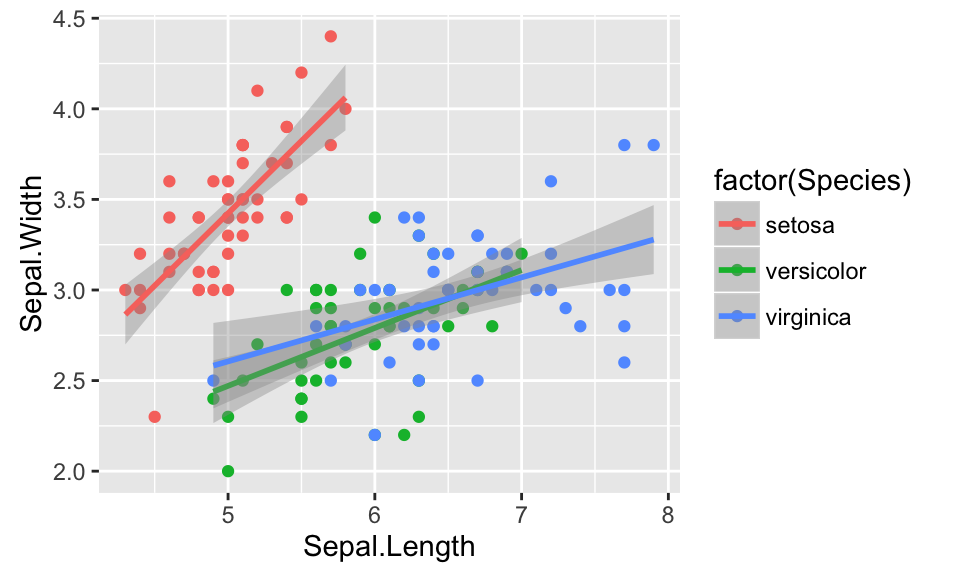

```r
#In case we want to add linear regression models to our scatterplot, simply add geom_smooth() to the ggplot. What we see as a grey shading around the regression lines is the predicted standard error. You can avoid that by adding se=F as an argument to geom_smooth
ggplot(iris_test,aes(x=Sepal.Length, y=Sepal.Width, colour = factor(Species))) +
  geom_point() +
  stat_smooth(method='lm')
```

##### Adding mean lines

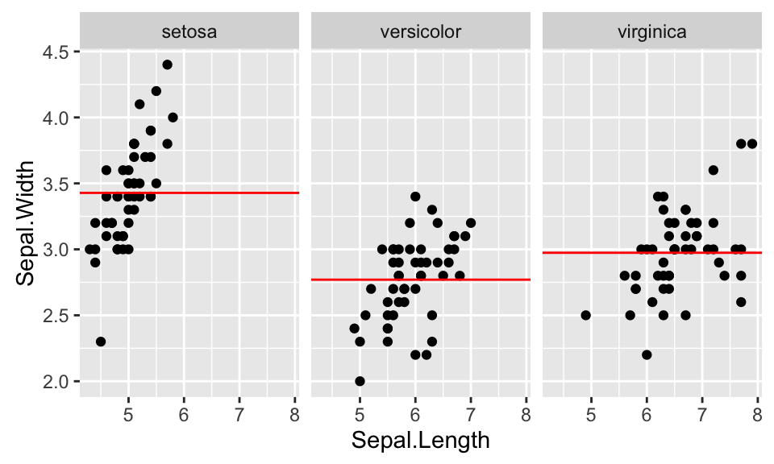

```r
#
library(dplyr)
means_iris <- iris_test %>%
  group_by(.,Species)%>%
  summarise(.,mean_sw=mean(Sepal.Width),sd_sw=sd(Sepal.Width))

ggplot(data=iris_test,aes(x=Sepal.Length, y=Sepal.Width)) +
  geom_point() +
  facet_wrap(~Species) +
  geom_hline(aes(yintercept=mean_sw),data=means_iris,colour='red')
```

##### mean+errorbar-plots

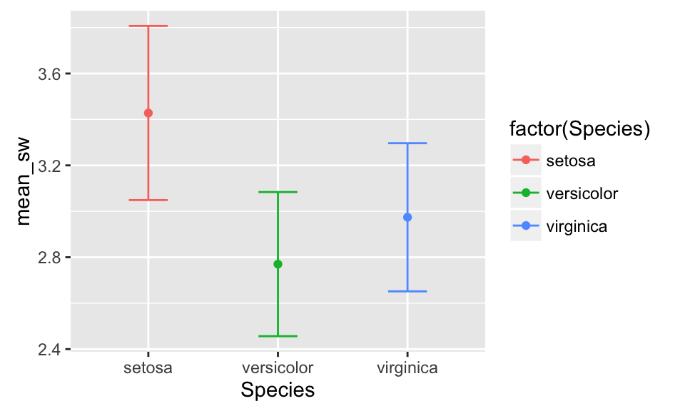

```r
#
ggplot(data=means_iris,aes(x=Species, y=mean_sw,colour=factor(Species))) +
  geom_point() +
  geom_errorbar(aes(ymin = mean_sw-sd_sw, ymax=mean_sw+sd_sw),width=.3)
```

#### How to add data from 2 different dataframes

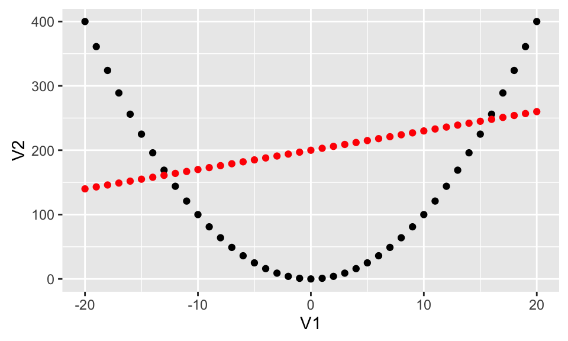

```r
#you can add the second dataset as a geom_point-layer
#problem: works only if both datasets have the same lengths
data1 <- as.data.frame(cbind(c(-20:20),c(-20:20)^2))
data2 <- as.data.frame(cbind(c(-20:20),c(-20:20)*3+200))

ggplot(data=data1,aes(x=V1, y=V2)) +
  geom_point() +
  geom_point(aes(x = data2$V1,y=data2$V2),colour=2)
```

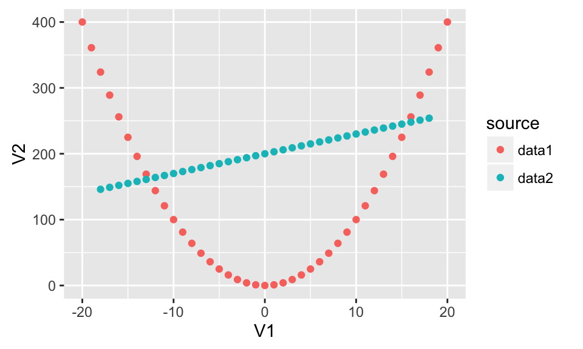

```r
#for cleaner code try to combine the dataframes if possible
#advantage: automatically generated legend, datasets can differ in length...
data1 <- as.data.frame(cbind(c(-20:20),c(-20:20)^2))
data2 <- as.data.frame(cbind(c(-18:18),c(-18:18)*3+200))
data3 <- rbind(data1,data2)
data3$source <- as.factor(c(rep('data1',length(data1$V1)),rep('data2',length(data2$V1))))
ggplot(data=data3,aes(x=V1,y=V2,colour=source))+
  geom_point()
```

#### How to save your plot

To make your work easily reproducible you should try to avoid saving your plots via clicking “Export”,“Save Plot”…  
A better solution is to use functions such as ggsave!

```r
plot1 <- ggplot(data=iris_test,aes(x=Sepal.Length, y=Sepal.Width, colour = factor(Species))) +
  geom_point()
ggsave('plot1.png',plot=plot1,width=6,height=4)
```

#### Some cool stuff

[figure not shown]

```r
sites <- read.csv("sites.csv", sep=" ", dec=".")
#This is just to show you what ggplot is capable of doing...
#Here we plot a simple map via ggmap to quickly visualize a few sites where samples for a study were taken
#Additionally, we use the package ggrepel to avoid overlapping of the station labels. This is extremely helpful since ggplot is not able to do that by itself.
library(ggrepel)
library(ggmap)
#Define borders for the map (min lon, min lat, max lon, max lat)
antarctica_coords<-c(-62, -65, -52, -60)
#we download a map from the google server. You can choose between multiple sources such as OpenStreetMap...
antarctica<-get_map(location=antarctica_coords,source="google",maptype="roadmap", crop=FALSE)

ggmap(antarctica)+
  geom_point(data=sites,aes(x=Longitude, y=Latitude),cex=0.25)+
  geom_text_repel(data=sites,aes(x=Longitude,y=Latitude,label = station,vjust=0.1,force=2)) +
  labs(x='Longitude',y='Latitude')
```